# Example: fitting the deterministic SEITL model

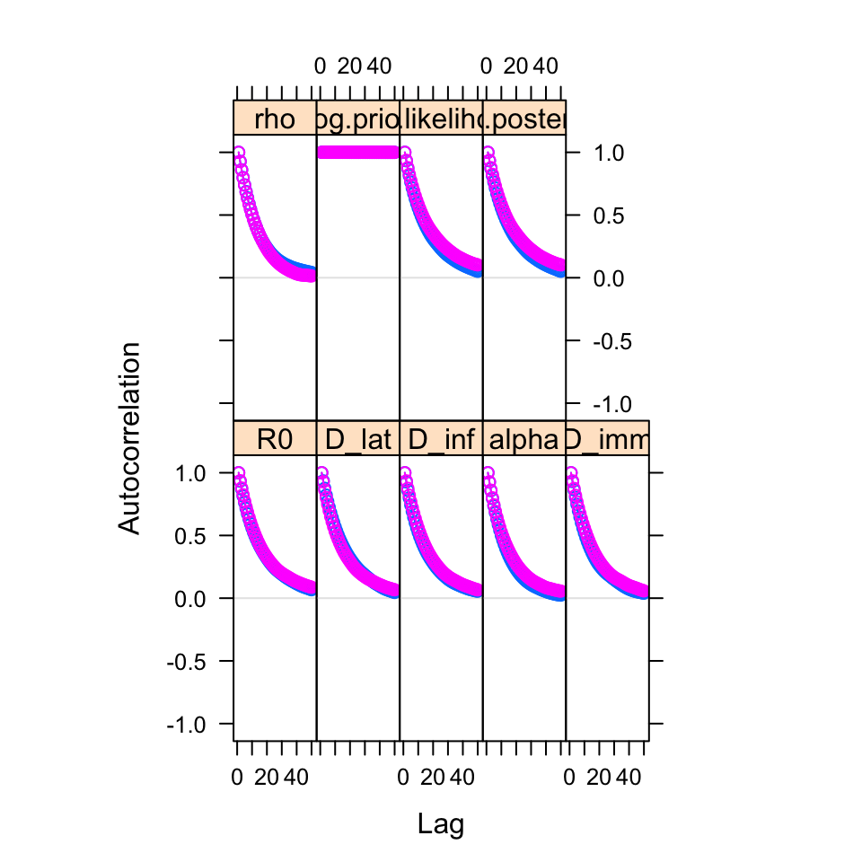

```r
# autocorrelation
acfplot(trace.burn)
```

Again, given the very high ESS, we can be quite generous in our choice of the thinning.

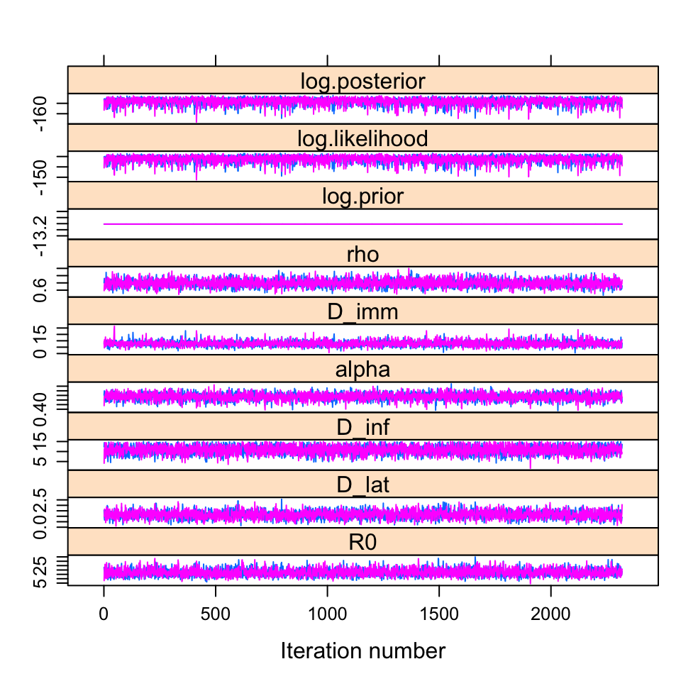

```r
# Thinning: let's keep 1 iteration every 40
trace.burn.thin <- burnAndThin(trace.burn, thin = 40)
xyplot(trace.burn.thin)
```

However, let's compare the thinned and unthinnned distributions.

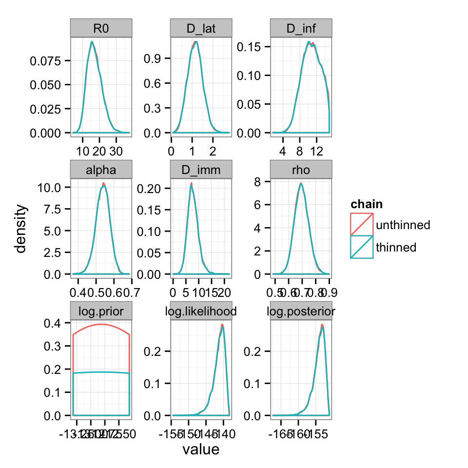

```r
# Note that plotPosteriorDensity can take a list of mcmc.list and will plot
# the different mcmc.list by combining their elements Let's plot the
# combined unthinned trace vs the combined thinned trace.
plotPosteriorDensity(list(unthinned = trace.burn, thinned = trace.burn.thin))
```

In contrast to the previous short-run, they are almost no difference between the thinned and unthinned chains. Indeed, with such a long chain, the clumpy autocorrelation has been averaged out!

In fact, there are several references that show that the longer (unthinned) chain usually yields better estimates of the true posterior than the shorter thinned chain, even for percentiles in the tail of the distribution. That said, thinning can be useful for other reasons, such as memory or time constraints in post-chain processing.

Now, we can compare whether the two independent chains, started at `theta1` and `theta2`, have converged to the same posterior distribution

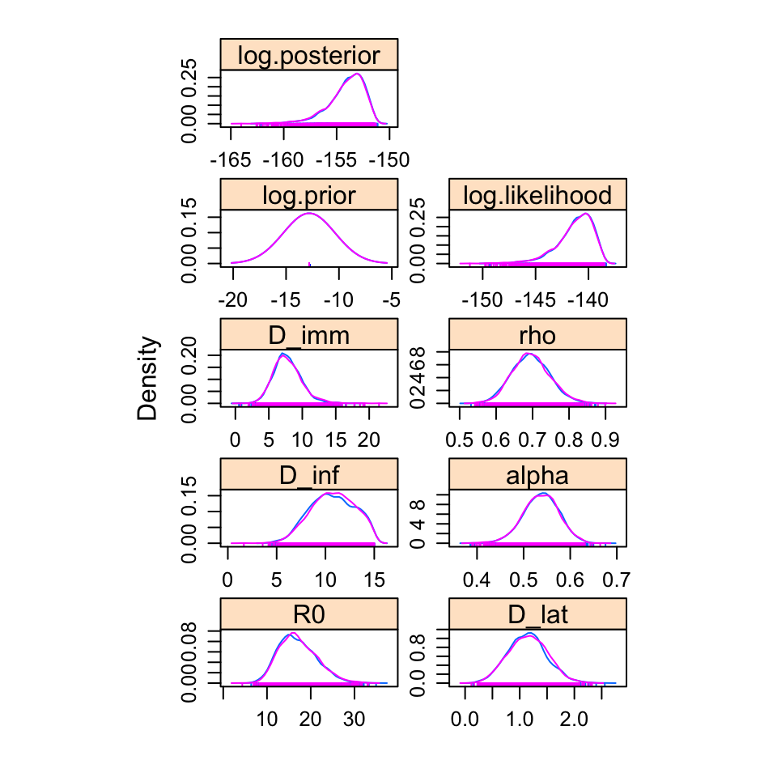

```r
densityplot(trace.burn.thin)
```

Since the chains have converged to the same posterior, we can use the combined estimates

```r
# the function summary combines the chains of a mcmc.list
summary(trace.burn.thin)
```

```
##
## Iterations = 1:2318
## Thinning interval = 1
## Number of chains = 2
## Sample size per chain = 2318
##
## 1. Empirical mean and standard deviation for each variable,
##    plus standard error of the mean:
##
##                     Mean      SD  Naive SE Time-series SE
## R0               17.0909 4.30760 0.0632650      0.0721890
## D_lat             1.1458 0.35552 0.0052214      0.0057899
## D_inf            10.7516 2.23701 0.0328546      0.0349587
## alpha             0.5373 0.03823 0.0005615      0.0006162
## D_imm             7.7800 2.11592 0.0310762      0.0315506
## rho               0.6957 0.05189 0.0007621      0.0007799
## log.prior       -12.8145 0.00000 0.0000000      0.0000000
## log.likelihood -141.2702 1.71514 0.0251900      0.0282695
## log.posterior  -154.0846 1.71514 0.0251900      0.0282695
##
## 2. Quantiles for each variable:
##
##                     2.5%       25%       50%       75%     97.5%
## R0                9.9720   13.9366   16.6412   19.9047   26.4282
## D_lat             0.4806    0.8984    1.1447    1.3817    1.8422
## D_inf             6.4954    9.1177   10.7736   12.4811   14.6550
## alpha             0.4588    0.5122    0.5386    0.5633    0.6098
## D_imm             4.1559    6.3534    7.6108    9.0465   12.5091
## rho               0.5987    0.6601    0.6942    0.7295    0.8023
## log.prior       -12.8145  -12.8145  -12.8145  -12.8145  -12.8145
## log.likelihood -145.5656 -142.1288 -140.9693 -140.0230 -138.8926
## log.posterior  -158.3801 -154.9433 -153.7838 -152.8375 -151.7071
```

Running several independent chains starting from different parts of the parameter space allows us to check whether the posterior distribution is multi-modal. If so, then we must be careful when combining the chains. For instance, an estimate of the mean computed with `summary` won't be meaningful for a parameter with a multi-modal posterior. By contrast, for a uni-modal posteriors, combining chains is an efficient way to increase the ESS and the precision of the posterior estimates. Furthermore, running several "shorter" chains in parallel is faster than running one "long" chain.

Finally, let's assess the fit of the deterministic SEITL model.

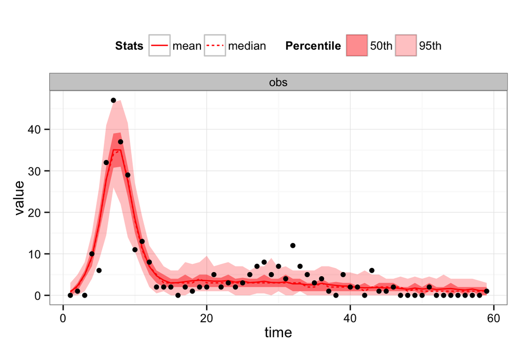

```r
# load data
data(FluTdC1971)

# the same init.state as for the fit
init.state <- c(S = 279, E = 0, I = 2, T = 3, L = 0, Inc = 0)

# by default plotPosteriorFit summarize the fit of 100 thetas sampled from
# the posterior
plotPosteriorFit(trace = trace, fitmodel = SEITL_deter, init.state = init.state,
    data = FluTdC1971)
```

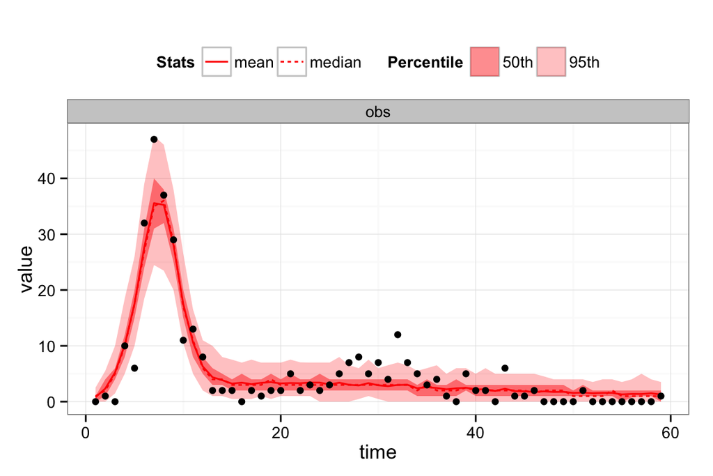

```r
# alternatively, one can plot the fit of the mean of the posterior (in this
# case the observation is replicated 100 times)
plotPosteriorFit(trace = trace, fitmodel = SEITL_deter, init.state = init.state,
    data = FluTdC1971, posterior.summary = "mean")
```

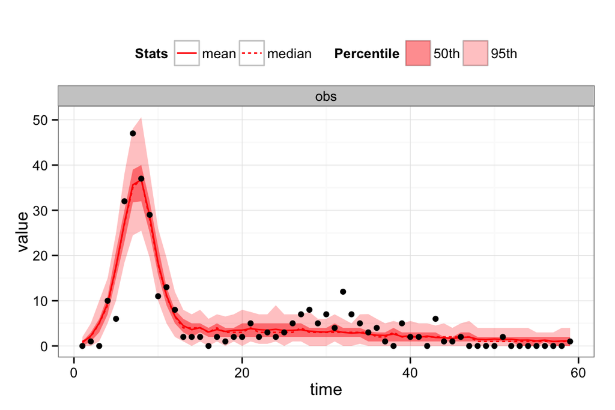

```r
# or using the maximum a posteriori (MAP) estimate
plotPosteriorFit(trace = trace, fitmodel = SEITL_deter, init.state = init.state,
    data = FluTdC1971, posterior.summary = "max")
```

Note that the 95% credible intervals (CI) for the posterior fit under the MAP captures the highest data point. By contrast, the fit of the second peak seems quite poor, even for the MAP.

You can now go back to the practical and look at the posterior correlations between the parameters.

# Correlations

The correlation of the posterior distribution can be plotted with `levelplot`.

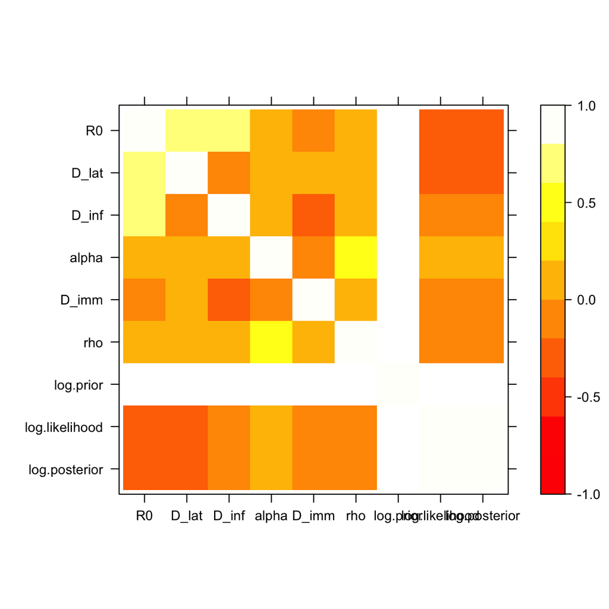

```r
# levelplot doesn't accept `mcmc.list`, we pass the first `mcmc` only.
levelplot(trace.burn.thin[[1]], col.regions = heat.colors(100))
```

Note the strong positive correlations (~0.8) between $R_0$ and $D_{lat}$ and between $R_0$ and $D_{inf}$. In order to explain the wide 95% CIs of $R_0$ and $D_{inf}$, let's have a look at the contact rate $\beta = R_0/D_{inf}$.

```r
with(as.data.frame(trace.burn.thin[[1]]), quantile(R0/D_inf, probs = c(0.025,
    0.25, 0.5, 0.75, 0.975)))
```

```
##     2.5%      25%      50%      75%    97.5%
## 1.091157 1.395928 1.573898 1.771753 2.203119
```

The posterior value of $\beta$ varies somewhat less than the posterior values of $R_0$ and $D_\mathrm{inf}$. Indeed, this parameter is constrained by the shape of the initial phase of the outbreak. Conversely, there are an infinite number of combinations of $R_0$ and $D_{inf}$ that lead to the same $\beta$, hence their wide 95% CIs. A second effect that could explain the high level of variation in $R_0$ is the very high attack rate. Once $R_0>5$ it doesn't make much difference whether $R_0$ is, say, 10 or 20.

We can also note that the posterior estimate of $D_{inf} = 11$ days (95% CI: $[6-15]$) is biologically unrealistic based on previous empirical estimates. However, our approach did not include any prior information as by default the `SEITL_deter` fitmodel comes with uniform priors for all parameters.

In order to include previous empirical information on $D_{lat}$ and $D_{inf}$, let's modify the `logPrior` of `SEITL_deter` as follows:

```r
SEITL_deter$logPrior <- function(theta) {

    # package with truncated normal distribution
    library(truncnorm)

    log.prior.R0 <- dunif(theta[["R0"]], min = 1, max = 50, log = TRUE)
    # normal distribution with mean = 2 and sd = 1 and truncated at 0
    log.prior.latent.period <- log(dtruncnorm(theta[["D_lat"]], a = 0, b = Inf,
        mean = 2, sd = 1))
    # normal distribution with mean = 2 and sd = 1 and truncated at 0
    log.prior.infectious.period <- log(dtruncnorm(theta[["D_inf"]], a = 0, b = Inf,
        mean = 2, sd = 1))
    log.prior.temporary.immune.period <- dunif(theta[["D_imm"]], min = 0, max = 50,
        log = TRUE)
    log.prior.probability.long.term.immunity <- dunif(theta[["alpha"]], min = 0,
        max = 1, log = TRUE)
    log.prior.reporting.rate <- dunif(theta[["rho"]], min = 0, max = 1, log = TRUE)

    return(log.prior.R0 + log.prior.latent.period + log.prior.infectious.period +
        log.prior.temporary.immune.period + log.prior.probability.long.term.immunity +
        log.prior.reporting.rate)

}
```

Note the choice of a truncated normal distribution since $D_{lat}$ and $D_{inf}$ must be positive.

You can now go back to the practical and run a MCMC with this informative prior.

# Informative priors

Here we combine both chains with informative priors and compare the posterior distribution with the one above.

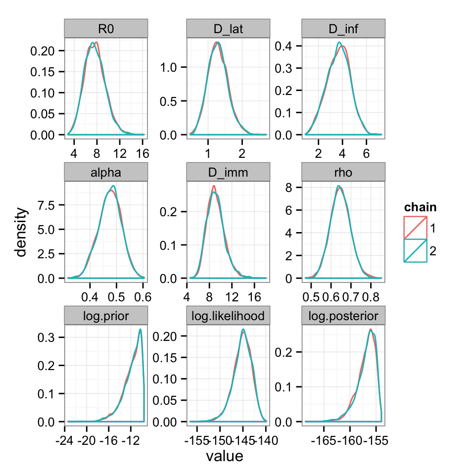

```r
# create mcmc object
trace.info1 <- mcmc(mcmc_SEITL_infoPrior_theta1$trace)
trace.info2 <- mcmc(mcmc_SEITL_infoPrior_theta2$trace)

# combine in a mcmc.list
trace.info <- mcmc.list(trace.info1, trace.info2)

# burn and thin as the chain with uniform prior (see above sections)
trace.info.burn.thin <- burnAndThin(trace.info, burn = 5000, thin = 40)

# check that both chains converged to the same posterior
plotPosteriorDensity(trace.info.burn.thin)
```

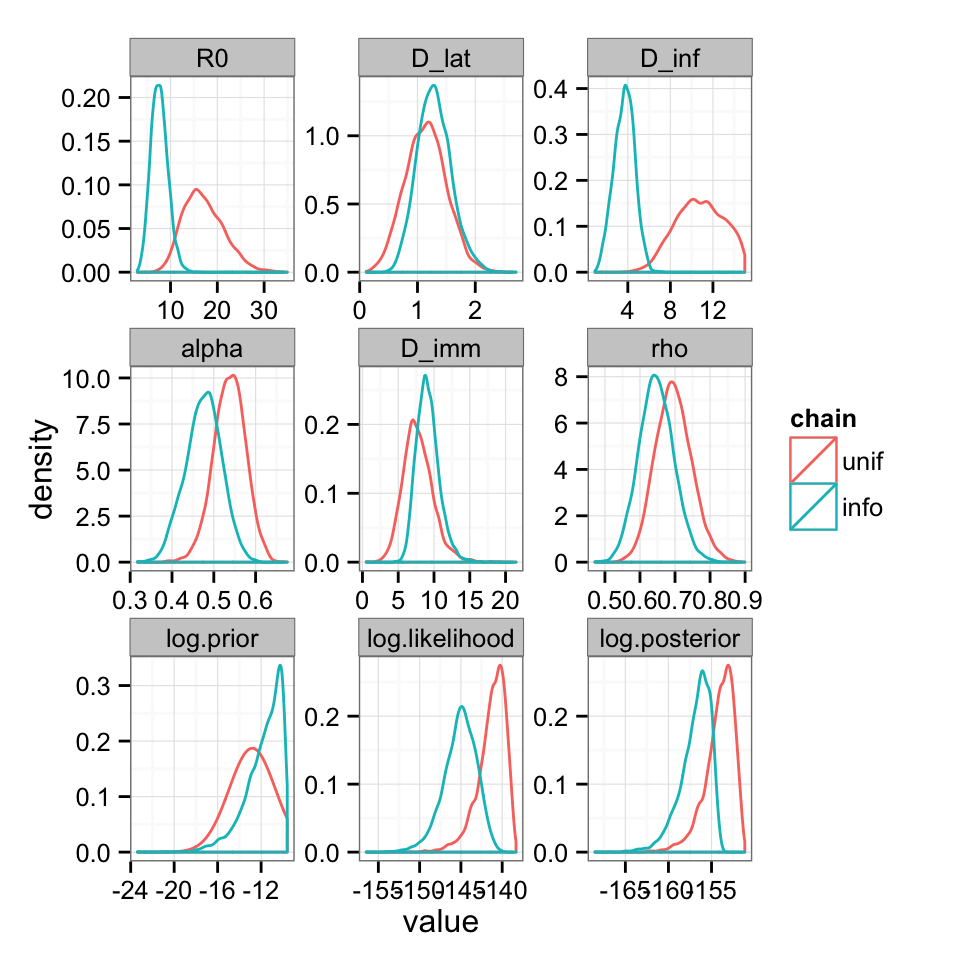

```r
# compare the effect of informative priors on the posterior distribution
plotPosteriorDensity(list(unif = trace.burn.thin, info = trace.info.burn.thin))
```

$R_0$ and $D_{inf}$ have very different posterior. This is expected since there is an informative prior on $D_{inf}$ and $R_0$ is strongly correlated to $D_{inf}$. Note also that the mode of all other parameters have changed, though less than $D_{inf}$ and $R_0$. This illustrate the influence that one prior can have on the full posterior distribution.

You can now go back to the practical.

# Model selection

```r
# combine the two chains in a data frame
trace.combined <- ldply(trace.info.burn.thin)

# take the mean of theta
theta.bar <- colMeans(trace.combined[SEITL_deter$theta.names])
print(theta.bar)
```

```
##        R0     D_lat     D_inf     alpha     D_imm       rho
## 7.6250928 1.2904394 3.6664971 0.4751491 9.1354413 0.6468514
```

```r
# compute its log-likelihood
init.state <- c(S = 279, E = 0, I = 2, T = 3, L = 0, Inc = 0)
log.like.theta.bar <- dTrajObs(SEITL_deter, theta.bar, init.state, data = FluTdC1971,
    log = TRUE)
print(log.like.theta.bar)
```

```
## [1] -142.84
```

```r
# and its deviance
D.theta.bar <- -2 * log.like.theta.bar
print(D.theta.bar)
```

```
## [1] 285.6799
```

```r
# the effective number of parameters
p.D <- var(-2 * trace.combined$log.likelihood)/2
print(p.D)
```

```
## [1] 8.116991
```

```r
# and finally the DIC
DIC <- D.theta.bar + 2 * p.D
print(DIC)
```

```
## [1] 301.9139
```

Follow this link to go back to the practical.